# Boston_Airbnb_Open_Data

```python
# Import libraries.
import pandas as pd
import numpy as np
import matplotlib.pyplot as plt
import seaborn as sns
%matplotlib inline

from tensorflow.keras.models import Sequential
from tensorflow.keras.layers import Dense,Dropout
from tensorflow.keras.callbacks import EarlyStopping

from sklearn.model_selection import train_test_split
from sklearn.preprocessing import StandardScaler
from sklearn.metrics import mean_squared_error

pd.set_option('display.max_columns',200)
pd.set_option('display.max_rows',200)

import warnings
warnings.filterwarnings('ignore')
warnings.simplefilter('ignore')
```

```python
# Load datasets.
calendar_bos=pd.read_csv('calendar.csv')
listings_bos=pd.read_csv('listings.csv')
reviews_bos=pd.read_csv('reviews.csv')
```

```python
# Check reviews data set.
print(reviews_bos.sample(1))
```

```
     listing_id        id        date  reviewer_id reviewer_name  \
511     3992208  39510018  2015-07-24     35513924           Ben

                                              comments
511  Sean was a great host - always there to answer...
```

For this reviews table, the comments are not easy to quantify. It is possible to use some machine learning algorithm to convert the comments to rate. But I am not familiar with it so I will just drop this table.

```python
# EDA: calendar.
print(calendar_bos.head())
print(calendar_bos.shape)
print(calendar_bos.info())
```

```
   listing_id        date available price
0    12147973  2017-09-05         f   NaN
1    12147973  2017-09-04         f   NaN
2    12147973  2017-09-03         f   NaN
3    12147973  2017-09-02         f   NaN
4    12147973  2017-09-01         f   NaN
(1308890, 4)
<class 'pandas.core.frame.DataFrame'>
RangeIndex: 1308890 entries, 0 to 1308889
Data columns (total 4 columns):
 #   Column      Non-Null Count    Dtype
---  ------      --------------    -----
 0   listing_id  1308890 non-null  int64
 1   date        1308890 non-null  object
 2   available   1308890 non-null  object
 3   price       643037 non-null   object
dtypes: int64(1), object(3)
memory usage: 39.9+ MB
None
```

```python
# Check the # of id
print(calendar_bos['listing_id'].nunique())
# Check unique value of available
print(calendar_bos['available'].unique())
# Check the # of unavailable (available=f)
print(calendar_bos[calendar_bos['available']=='f'].shape)
# Check the # of NAN in price column
print(calendar_bos['price'].isnull().sum())
```

```
3585
['f' 't']
(665853, 4)
665853
```

There are 3585 unique ids in this calendar table. The date, available and price columns are object data type. It might needed to be converted to other data type later. There are 665853 rows with no price and this rows with available equals to f(false).  
I will seperate this table into 2 tables. One with data with price and available date. The other with data with NAN and unavailable date. I will use the latter one to find out on which month Boston are more busy and use the first one to calculate the average price each month.

```python
def divide_table(df):
    '''Take the calendar datatable, return the df_1 which contains avaliable houses and df_2 which contaings reserved houses.'''
    # Convert date to timestamp
    df['date']=pd.to_datetime(df['date'])

    # Make a talbe with all unavailable date
    df_2=df[df['available']=='f']
    df_2['month']=df_2['date'].dt.month

    # Convert price to float
    df_1=df[df['available']=='t']
    df_1['price']=df_1['price'].str.replace('$','')
    df_1['price']=df_1['price'].str.replace(',','')
    df_1['price']=df_1['price'].astype(float)
    df_1['month']=df_1['date'].dt.month

    return df_1, df_2
```

# Question1: In which season does Boston have the most visitors?

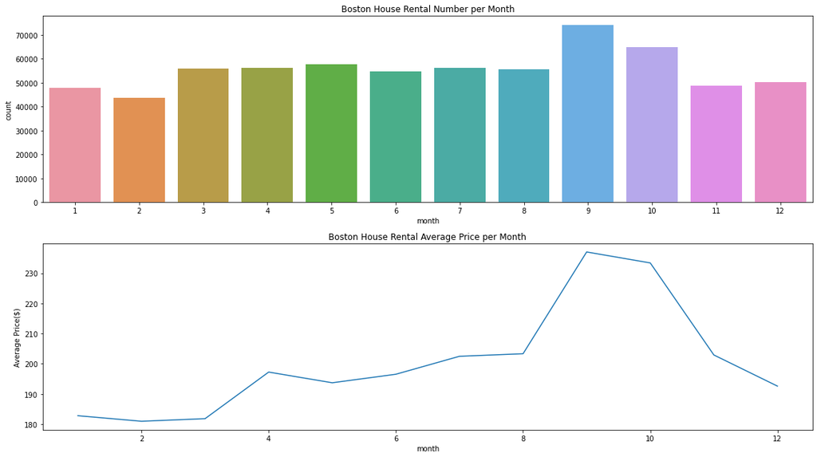

```python
# Plot the two tables.
calendar_bos_avg, calendar_bos_nan=divide_table(calendar_bos)

fig, ax=plt.subplots(2,1,figsize=(16,9))

ax[0].set_title('Boston House Rental Number per Month')
sns.countplot(calendar_bos_nan['month'],ax=ax[0])

ax[1].set_title('Boston House Rental Average Price per Month')
ax[1]=calendar_bos_avg.groupby('month').mean()['price'].plot()
ax[1].set_ylabel('Average Price($)')

plt.tight_layout();
```

# Answer:

From this plot it is obvious to see the most popular season to visit Boston is the fall. The most unpopular season is the winter. This is reasonable since the fall of Boston is beautiful and cosy, people could walk the freedom trail and even go to New Hampshire to visit white mountain. In winter, espically February, Boston is super cold. It is highly possible to have snowstorm, which makes visiting Boston a bad choice.  
The price of rental also suggests this conclusion. From Septerber to October the average price is the highest in the year while in February the average price is the lowest in the year.

```python
# EDA listings table
print(listings_bos.head())
print(listings_bos.shape)
print(listings_bos.info())
```

```
         id                            listing_url       scrape_id  \
0  12147973  https://www.airbnb.com/rooms/12147973  20160906204935
1   3075044   https://www.airbnb.com/rooms/3075044  20160906204935
2      6976      https://www.airbnb.com/rooms/6976  20160906204935
3   1436513   https://www.airbnb.com/rooms/1436513  20160906204935
4   7651065   https://www.airbnb.com/rooms/7651065  20160906204935

  last_scraped                                           name  \
0   2016-09-07                     Sunny Bungalow in the City
1   2016-09-07              Charming room in pet friendly apt
2   2016-09-07               Mexican Folk Art Haven in Boston
3   2016-09-07  Spacious Sunny Bedroom Suite in Historic Home
4   2016-09-07                            Come Home to Boston

                                             summary  \
```

[output cut: 368 more lines]

Clearly this data set has too many info. I will drop the unrelated columns firstly and then change data types and fill in missing values in the dataset with less columns. I will have a exploratory data analysis and then build a model to predict the price of house rental on Aribnb.

```python
# Check all the column names.
listings_bos.columns
```

```
Index(['id', 'listing_url', 'scrape_id', 'last_scraped', 'name', 'summary',
       'space', 'description', 'experiences_offered', 'neighborhood_overview',
       'notes', 'transit', 'access', 'interaction', 'house_rules',
       'thumbnail_url', 'medium_url', 'picture_url', 'xl_picture_url',
       'host_id', 'host_url', 'host_name', 'host_since', 'host_location',
       'host_about', 'host_response_time', 'host_response_rate',
       'host_acceptance_rate', 'host_is_superhost', 'host_thumbnail_url',
       'host_picture_url', 'host_neighbourhood', 'host_listings_count',
       'host_total_listings_count', 'host_verifications',
       'host_has_profile_pic', 'host_identity_verified', 'street',
       'neighbourhood', 'neighbourhood_cleansed',
       'neighbourhood_group_cleansed', 'city', 'state', 'zipcode', 'market',
       'smart_location', 'country_code', 'country', 'latitude', 'longitude',
       'is_location_exact', 'property_type', 'room_type', 'accommodates',
       'bathrooms', 'bedrooms', 'beds', 'bed_type', 'amenities', 'square_feet',
       'price', 'weekly_price', 'monthly_price', 'security_deposit',
       'cleaning_fee', 'guests_included', 'extra_people', 'minimum_nights',
       'maximum_nights', 'calendar_updated', 'has_availability',
       'availability_30', 'availability_60', 'availability_90',
       'availability_365', 'calendar_last_scraped', 'number_of_reviews',
       'first_review', 'last_review', 'review_scores_rating',
       'review_scores_accuracy', 'review_scores_cleanliness',
       'review_scores_checkin', 'review_scores_communication',
       'review_scores_location', 'review_scores_value', 'requires_license',
       'license', 'jurisdiction_names', 'instant_bookable',
       'cancellation_policy', 'require_guest_profile_picture',
       'require_guest_phone_verification', 'calculated_host_listings_count',
       'reviews_per_month'],
      dtype='object')
```

```python
# Check the unique values of neighbourhood column.
listings_bos.neighbourhood.unique()
```

```
array(['Roslindale', nan, 'Jamaica Plain', 'Mission Hill',
       'Fenway/Kenmore', 'Back Bay', 'Leather District', 'Chinatown',
       'Hyde Park', 'North End', 'Roxbury', 'South End', 'Mattapan',
       'East Boston', 'South Boston', 'Charlestown', 'West End',
       'Beacon Hill', 'Theater District', 'Downtown Crossing', 'Downtown',
       'Financial District', 'Government Center', 'Allston-Brighton',
       'West Roxbury', 'Chestnut Hill', 'Dorchester', 'Brookline',
       'Cambridge', 'Somerville', 'Harvard Square'], dtype=object)
```

```python
# Make a list with column needed.
col_num=['accommodates', 'bathrooms', 'bedrooms', 'beds', 'square_feet', 'guests_included','review_scores_value','reviews_per_month']
col_cat=['neighbourhood','property_type','room_type','bed_type','amenities']
col_response=['price']
```

```python
# Combine the needed columns to make a new table.
listings_clean=listings_bos[col_num+col_cat+col_response]
listings_clean.head()
```

|  | accommodates | bathrooms | bedrooms | beds | square_feet | guests_included | review_scores_value | reviews_per_month | neighbourhood | property_type | room_type | bed_type | amenities | price |
| --- | --- | --- | --- | --- | --- | --- | --- | --- | --- | --- | --- | --- | --- | --- |
| 0 | 4 | 1.5 | 2.0 | 3.0 | NaN | 1 | NaN | NaN | Roslindale | House | Entire home/apt | Real Bed | {TV,"Wireless Internet",Kitchen,"Free Parking ... | $250.00 |
| 1 | 2 | 1.0 | 1.0 | 1.0 | NaN | 0 | 9.0 | 1.30 | Roslindale | Apartment | Private room | Real Bed | {TV,Internet,"Wireless Internet","Air Conditio... | $65.00 |
| 2 | 2 | 1.0 | 1.0 | 1.0 | NaN | 1 | 10.0 | 0.47 | Roslindale | Apartment | Private room | Real Bed | {TV,"Cable TV","Wireless Internet","Air Condit... | $65.00 |
| 3 | 4 | 1.0 | 1.0 | 2.0 | NaN | 2 | 10.0 | 1.00 | NaN | House | Private room | Real Bed | {TV,Internet,"Wireless Internet","Air Conditio... | $75.00 |
| 4 | 2 | 1.5 | 1.0 | 2.0 | NaN | 1 | 10.0 | 2.25 | Roslindale | House | Private room | Real Bed | {Internet,"Wireless Internet","Air Conditionin... | $79.00 |

```python
# Check the columns info.
listings_clean.info()
```

```
<class 'pandas.core.frame.DataFrame'>
RangeIndex: 3585 entries, 0 to 3584
Data columns (total 14 columns):
 #   Column               Non-Null Count  Dtype
---  ------               --------------  -----
 0   accommodates         3585 non-null   int64
 1   bathrooms            3571 non-null   float64
 2   bedrooms             3575 non-null   float64
 3   beds                 3576 non-null   float64
 4   square_feet          56 non-null     float64
 5   guests_included      3585 non-null   int64
 6   review_scores_value  2764 non-null   float64
 7   reviews_per_month    2829 non-null   float64
 8   neighbourhood        3042 non-null   object
 9   property_type        3582 non-null   object
 10  room_type            3585 non-null   object
 11  bed_type             3585 non-null   object
 12  amenities            3585 non-null   object
 13  price                3585 non-null   object
dtypes: float64(6), int64(2), object(6)
memory usage: 392.2+ KB
```

```python
# Drop the square_feet column since it only has 56 values.
listings_clean.drop('square_feet', axis=1, inplace=True)
```

```python
# Change the data type of price to int.
listings_clean['price']=listings_clean['price'].apply(lambda x: int(x[1:-3].replace(',','')))
```

# Question2: What influce the price of houses in Boston?

```python
# Fill the NANs with the median of each column.
# Here I would like to see a general trend between the varibales with price.
# For this reason I will temporarily fill missing values with the median.
listings_clean[['bathrooms','bedrooms','beds','review_scores_value','reviews_per_month']]=listings_clean[['bathrooms','bedrooms','beds','review_scores_value','reviews_per_month']].apply(lambda x: x.fillna(x.median()))
```

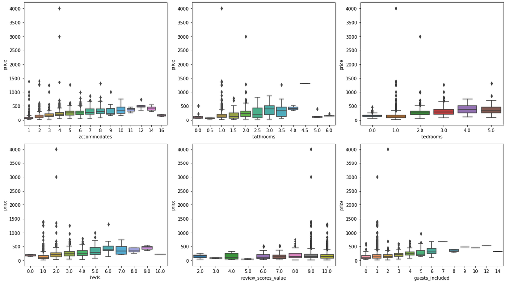

```python
# Plot the numeric variables with price.
fig,ax=plt.subplots(2,3,figsize=(16,9))

sns.boxplot(data=listings_clean, x='accommodates',y='price',ax=ax[0][0])
sns.boxplot(data=listings_clean, x='bathrooms',y='price',ax=ax[0][1])
sns.boxplot(data=listings_clean, x='bedrooms',y='price',ax=ax[0][2])
sns.boxplot(data=listings_clean, x='beds',y='price',ax=ax[1][0])
sns.boxplot(data=listings_clean, x='review_scores_value',y='price',ax=ax[1][1])
sns.boxplot(data=listings_clean, x='guests_included',y='price',ax=ax[1][2])
plt.tight_layout();
```

```python
# Check the distribution of prices.
listings_clean['price'].describe()
```

```
count    3585.000000
mean      173.925802
std       148.331321
min        10.000000
25%        85.000000
50%       150.000000
75%       220.000000
max      4000.000000
Name: price, dtype: float64
```

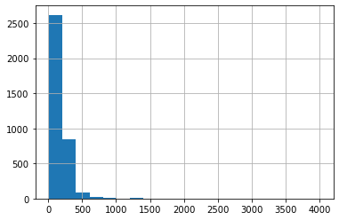

```python
listings_clean['price'].hist(bins=20);
```

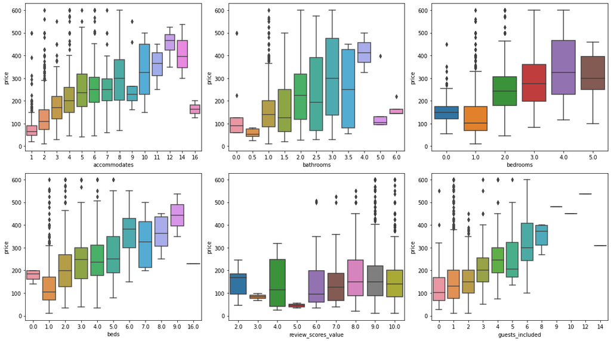

```python
# Remove outliers in the data and plot the numeric variables with price.
fig,ax=plt.subplots(2,3,figsize=(16,9))
listings_clean=listings_clean[listings_clean['price']<=600]

sns.boxplot(data=listings_clean, x='accommodates',y='price',ax=ax[0][0])
sns.boxplot(data=listings_clean, x='bathrooms',y='price',ax=ax[0][1])
sns.boxplot(data=listings_clean, x='bedrooms',y='price',ax=ax[0][2])
sns.boxplot(data=listings_clean, x='beds',y='price',ax=ax[1][0])
sns.boxplot(data=listings_clean, x='review_scores_value',y='price',ax=ax[1][1])
sns.boxplot(data=listings_clean, x='guests_included',y='price',ax=ax[1][2])
plt.tight_layout();
```

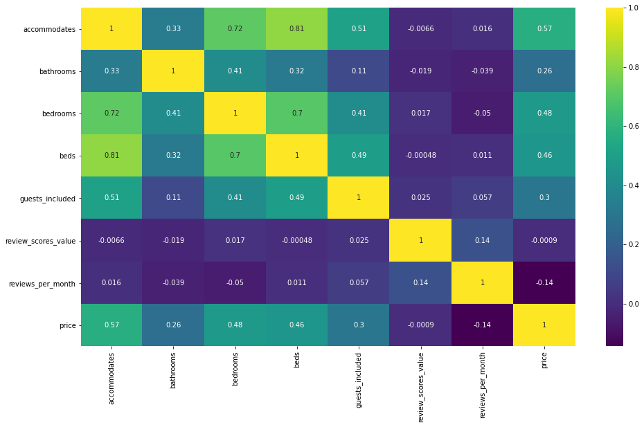

```python
# Plot a heat map to see the correlations between numeric variables.
plt.figure(figsize=(16,9))
sns.heatmap(listings_clean.corr(),annot=True, cmap='viridis');
```

From the plot above it is clearly to see that with more accomodates, bathrooms, bedrooms, beds and guests, the price of house is higher. This is reasonable since the more people/rooms the bigger the house, which makes the price higher. The heatmap shows the correlation of these variables. Since the correlation is smaller than 0.95, I will use all these variables in building the model later.  
It is intersting that the review score is not related with the price of houses. For this reason I will delete the review_score_value and reviews_per_month column when I build the model in the next section.

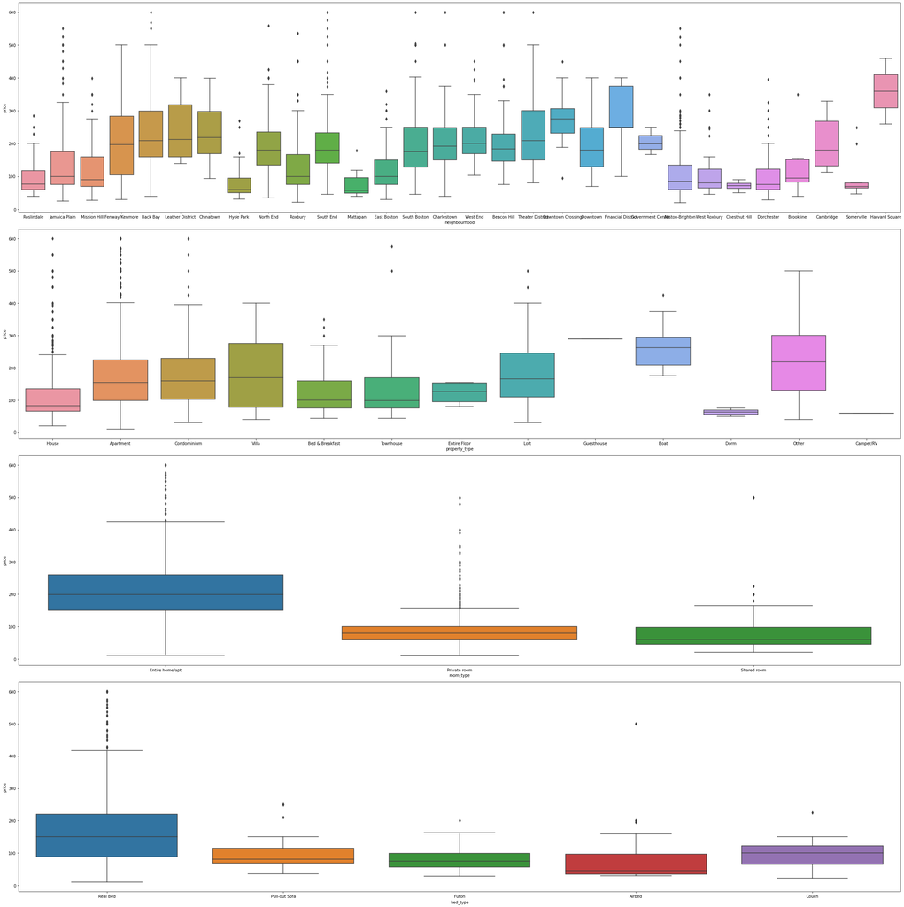

```python
# Plot the category variables with price.
fig,ax=plt.subplots(4,1,figsize=(32,32))

sns.boxplot(data=listings_clean, x='neighbourhood',y='price',ax=ax[0])

sns.boxplot(data=listings_clean, x='property_type',y='price',ax=ax[1])

sns.boxplot(data=listings_clean, x='room_type',y='price',ax=ax[2])

sns.boxplot(data=listings_clean, x='bed_type',y='price',ax=ax[3])

plt.tight_layout();
```

From the plot above it is clear to see the location, type of the house, type of the room and type of the bed all influence the price of house. These categorical varibales will be used in the building of the model to predict the price of house rentals in Boston.

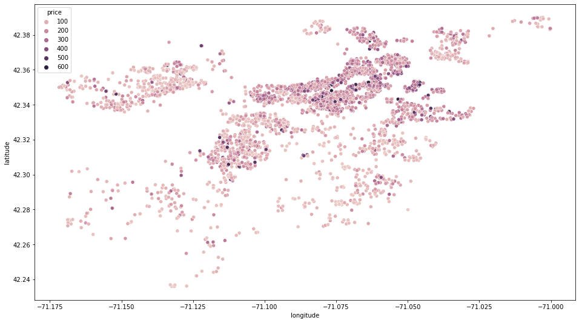

```python
# Plot the latitude and longitude.
plt.figure(figsize=(16,9))
listings_bos['price']=listings_bos['price'].apply(lambda x: int(x[1:-3].replace(',','')))
sns.scatterplot(data=listings_bos[listings_bos['price']<=600],y='latitude',x='longitude',hue='price');
```

# Question3: Is it possible to build a model to predict the price of house rental around Boston area?

```python
# Clean the amenities column and turn it into dummy varibales.
listings_clean['amenities']=listings_clean['amenities'].apply(lambda x: x.replace('{','').replace('}','').replace('"',''))
listings_clean['amenities']=listings_clean['amenities'].str.split(',')
```

```python
listings_clean['amenities']
```

```
0       [TV, Wireless Internet, Kitchen, Free Parking ...
1       [TV, Internet, Wireless Internet, Air Conditio...
2       [TV, Cable TV, Wireless Internet, Air Conditio...
3       [TV, Internet, Wireless Internet, Air Conditio...
4       [Internet, Wireless Internet, Air Conditioning...
                              ...
3580    [Internet, Wireless Internet, Air Conditioning...
3581    [TV, Internet, Wireless Internet, Air Conditio...
3582    [translation missing: en.hosting_amenity_49, t...
3583    [Kitchen, Gym, Family/Kid Friendly, Washer, Dr...
3584    [Wireless Internet, Kitchen, Essentials, trans...
Name: amenities, Length: 3547, dtype: object
```

```python
# Find the unique values of amenities.
amenities_unique=[]
for value in listings_clean['amenities']:
    for i in range(len(value)):
        if value[i] not in amenities_unique and value[i]!='':
            amenities_unique.append(value[i])
amenities_unique
```

```
['TV',
 'Wireless Internet',
 'Kitchen',
 'Free Parking on Premises',
 'Pets live on this property',
 'Dog(s)',
 'Heating',
 'Family/Kid Friendly',
 'Washer',
 'Dryer',
 'Smoke Detector',
 'Fire Extinguisher',
 'Essentials',
 'Shampoo',
 'Laptop Friendly Workspace',
 'Internet',
 'Air Conditioning',
 'Pets Allowed',
 'Carbon Monoxide Detector',
 'Lock on Bedroom Door',
 'Hangers',
 'Hair Dryer',
 'Iron',
 'Cable TV',
 'First Aid Kit',
 'Safety Card',
 'translation missing: en.hosting_amenity_49',
 'translation missing: en.hosting_amenity_50',
 'Gym',
 'Breakfast',
 'Indoor Fireplace',
 'Cat(s)',
 '24-Hour Check-in',
 'Hot Tub',
 'Buzzer/Wireless Intercom',
 'Other pet(s)',
 'Washer / Dryer',
 'Smoking Allowed',
 'Suitable for Events',
 'Wheelchair Accessible',
 'Elevator in Building',
 'Pool',
 'Doorman',
 'Paid Parking Off Premises',
 'Free Parking on Street']
```

```python
# Make the dataframe with dummy variables.
amenity_array=np.array([listings_clean['amenities'].map(lambda x: amenity in x) for amenity in amenities_unique])
print(amenity_array.shape)
amenity_array=amenity_array.T
print(amenity_array.shape)

pd.DataFrame(amenity_array,columns=amenities_unique)
```

```
(45, 3547)
(3547, 45)
```

|  | TV | Wireless Internet | Kitchen | Free Parking on Premises | Pets live on this property | Dog(s) | Heating | Family/Kid Friendly | Washer | Dryer | Smoke Detector | Fire Extinguisher | Essentials | Shampoo | Laptop Friendly Workspace | Internet | Air Conditioning | Pets Allowed | Carbon Monoxide Detector | Lock on Bedroom Door | Hangers | Hair Dryer | Iron | Cable TV | First Aid Kit | Safety Card | translation missing: en.hosting_amenity_49 | translation missing: en.hosting_amenity_50 | Gym | … |
| --- | --- | --- | --- | --- | --- | --- | --- | --- | --- | --- | --- | --- | --- | --- | --- | --- | --- | --- | --- | --- | --- | --- | --- | --- | --- | --- | --- | --- | --- | --- |
| 0 | True | True | True | True | True | True | True | True | True | True | True | True | True | True | True | False | False | False | False | False | False | False | False | False | False | False | False | False | False | … |
| 1 | True | True | True | False | True | True | True | True | True | True | True | True | True | True | False | True | True | True | True | True | True | True | True | False | False | False | False | False | False | … |
| 2 | True | True | True | True | False | False | True | False | True | True | True | False | True | True | False | False | True | False | True | True | False | False | False | True | True | True | True | True | False | … |
| 3 | True | True | True | True | False | False | True | False | True | True | True | True | True | True | True | True | True | False | True | False | True | True | True | False | True | True | False | False | True | … |
| 4 | False | True | True | False | False | False | True | False | False | False | True | False | True | True | False | True | True | False | True | False | True | True | True | False | True | False | False | False | False | … |
| ... | ... | ... | ... | ... | ... | ... | ... | ... | ... | ... | ... | ... | ... | ... | ... | ... | ... | ... | ... | ... | ... | ... | ... | ... | ... | ... | ... | ... | ... | … |
| 3542 | False | True | True | True | False | False | True | True | False | False | True | True | True | True | True | True | True | False | True | True | True | True | True | False | False | False | False | False | False | … |
| 3543 | True | True | True | True | True | False | True | True | True | True | True | True | True | True | True | True | True | True | True | False | True | True | False | False | False | False | False | False | True | … |
| 3544 | False | False | False | False | False | False | False | False | False | False | False | False | False | False | False | False | False | False | False | False | False | False | False | False | False | False | True | True | False | … |
| 3545 | False | False | True | False | False | False | False | True | True | True | False | False | True | False | False | False | False | False | False | False | True | False | False | False | False | False | False | True | True | … |
| 3546 | False | True | True | False | False | False | False | False | False | False | False | False | True | False | False | False | False | False | False | False | False | False | False | False | False | False | True | True | False | … |

3547 rows × 45 columns

```python
# Make the dataframe used in modeling.
# Since the amenity was seperated to dummy variables, the original amenity column needed to be dropped.
# Review_scores_value and reviews_per_month are not related with price, hence these columns were dropped.
listings_clean=pd.concat([listings_clean,pd.DataFrame(amenity_array,columns=amenities_unique)],axis=1)
listings_clean.drop('amenities',axis=1,inplace=True)
listings_clean.drop('review_scores_value',axis=1,inplace=True)
listings_clean.drop('reviews_per_month',axis=1,inplace=True)
listings_clean=pd.get_dummies(listings_clean,columns=['neighbourhood','property_type','room_type','bed_type'])
listings_clean.head()
```

|  | accommodates | bathrooms | bedrooms | beds | guests_included | price | TV | Wireless Internet | Kitchen | Free Parking on Premises | Pets live on this property | Dog(s) | Heating | Family/Kid Friendly | Washer | Dryer | Smoke Detector | Fire Extinguisher | Essentials | Shampoo | Laptop Friendly Workspace | Internet | Air Conditioning | Pets Allowed | Carbon Monoxide Detector | Lock on Bedroom Door | Hangers | Hair Dryer | Iron | … |
| --- | --- | --- | --- | --- | --- | --- | --- | --- | --- | --- | --- | --- | --- | --- | --- | --- | --- | --- | --- | --- | --- | --- | --- | --- | --- | --- | --- | --- | --- | --- |
| 0 | 4.0 | 1.5 | 2.0 | 3.0 | 1.0 | 250.0 | True | True | True | True | True | True | True | True | True | True | True | True | True | True | True | False | False | False | False | False | False | False | False | … |
| 1 | 2.0 | 1.0 | 1.0 | 1.0 | 0.0 | 65.0 | True | True | True | False | True | True | True | True | True | True | True | True | True | True | False | True | True | True | True | True | True | True | True | … |
| 2 | 2.0 | 1.0 | 1.0 | 1.0 | 1.0 | 65.0 | True | True | True | True | False | False | True | False | True | True | True | False | True | True | False | False | True | False | True | True | False | False | False | … |
| 3 | 4.0 | 1.0 | 1.0 | 2.0 | 2.0 | 75.0 | True | True | True | True | False | False | True | False | True | True | True | True | True | True | True | True | True | False | True | False | True | True | True | … |
| 4 | 2.0 | 1.5 | 1.0 | 2.0 | 1.0 | 79.0 | False | True | True | False | False | False | True | False | False | False | True | False | True | True | False | True | True | False | True | False | True | True | True | … |

```python
# Drop the rows with missing values.
# Since the model built later cannot recognize missing values, we need to deal with them.
# The easiest way is to drop these missing values. Compared with filling the values with 0 or mean, drop values might be a better choice.
listings_clean=listings_clean.dropna(axis=0)
```

```python
listings_clean.shape
```

```
(3509, 102)
```

## Time to build the model!!!

```python
# Train test split.
X=listings_clean.drop('price',axis=1)
y=listings_clean['price']

X_train, X_test, y_train, y_test = train_test_split(X, y, test_size=0.3, random_state=42)

scaler=StandardScaler()
X_train=scaler.fit_transform(X_train)
X_test=scaler.transform(X_test)
```

```python
# Set early stop point.
early_stop=EarlyStopping(monitor='val_loss',mode='min')
```

```python
# Build the neural network.
model=Sequential()
model.add(Dense(100,activation='relu'))
model.add(Dropout(0.1))
model.add(Dense(50,activation='relu'))
model.add(Dropout(0.1))
model.add(Dense(25,activation='relu'))
model.add(Dropout(0.1))
model.add(Dense(12,activation='relu'))
model.add(Dense(1))
model.compile(optimizer='adam',loss='mse')
```

```python
# Fit the model.
model.fit(x=X_train,y=y_train,
          validation_data=(X_test,y_test),
          batch_size=64,epochs=100,
          callbacks=[early_stop])
```

```
<tensorflow.python.keras.callbacks.History at 0x1a5942c7160>
```

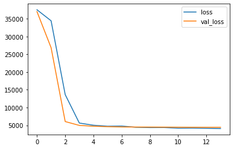

```python
# Check the loss of training set and validation set.
losses=pd.DataFrame(model.history.history)
losses.plot()
```

[output not shown]

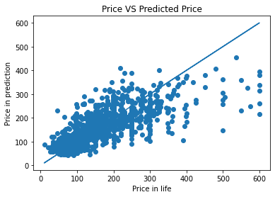

```python
# Predict the price and calculate the MSE.
predictions=model.predict(X_test)
print(mean_squared_error(y_test, predictions))
print(np.sqrt(mean_squared_error(y_test, predictions)))
plt.scatter(y_test,predictions)
plt.plot(y_test,y_test)
plt.title('Price VS Predicted Price')
plt.xlabel('Price in life')
plt.ylabel('Price in prediction');
```

[output not shown]

```python
# Make a table to compare the predicted price and price in reality.
pred=np.round(predictions.reshape(-1))
price=(np.array(y_test.reset_index(drop=True)))
pd.DataFrame([pred,price],index=['price','prediction']).T.sample(10)
```

|  | price | prediction |
| --- | --- | --- |
| 770 | 82.0 | 100.0 |
| 707 | 310.0 | 199.0 |
| 1009 | 196.0 | 150.0 |
| 438 | 207.0 | 200.0 |
| 922 | 274.0 | 286.0 |
| 601 | 58.0 | 68.0 |
| 296 | 254.0 | 300.0 |
| 781 | 128.0 | 135.0 |
| 330 | 125.0 | 135.0 |
| 671 | 259.0 | 600.0 |